# Coronary Heart Disease and Stroke Mortality Rate

2022-11-02

Group Number: 317B

Group Member: Elli Houtakker, Nolan You, Logan Begin, Thong Nguyen, Sharvil Dave

## Introduction

Strokes and heart disease are among the leading causes of death in the United States. Medical data analysis is required for research in order to figure out how to better treat patients, which is required to save lives. In this project, we are analyzing a collection of data on heart disease and stroke deaths in order to identify their roots and causes. This information is obtained directly from the CDC, which obtains it from state governments. Through this analysis, we will look at factors demographic information, like sex, age, and race, to find associations between those variables and the occurrence of heart disease and stroke. We believe that sex, age, and race are related to strokes and heart attacks. We believe there is an association between sex, age, and race and stroke and heart disease mortality rates.

## Background

In the United States, coronary heart disease is the leading cause of death for both men and women of all racial and ethnic groups, and a stroke occurs every 40 seconds[^1].Coronary artery disease, heart attack, arrhythmia, heart failure, high blood pressure, and other heart conditions are all examples of cardiovascular disease. Many of the symptoms of heart disease go unnoticed by the patient until something major happens. Diabetes, obesity, an unhealthy diet, and a lack of physical activity are all risk factors for heart disease, but it can also be inherited.[^2]. Because cardiovascular disease is a risk for everyone, many organizations study and research the effects as well as the causes in order to prevent the societal impact from continuing. The Division for Heart Disease and Stroke Prevention, Million Hearts, and WISEWOMEN are among these organizations. [^3].

Our project will examine the relationships between stroke and coronary heart disease, as well as the relationship between their mortality rates and patient characteristics, using the data provided. The National Vital Statistics System, a division of the Centers for Disease Control and Prevention, collected this data set, which can be found directly on [CDC website](https://chronicdata.cdc.gov/Heart-Disease-Stroke-Prevention/Rates-and-Trends-in-Heart-Disease-and-Stroke-Morta/7b9s-s8ck). The Federal Government agency collects data from state medical records in order to analyze the prevalence of cardiovascular disease in the United States and make this information available to the public through the CDC website. The data collected by the CDC is used to provide information to help people make decisions to protect themselves from illness or death, as well as to provide a better understanding on diseases, prevention, and other topics. We will be analyzing county population estimates of stroke and coronary heart disease mortality rates from 1999 to 2019-collected at the end of each year-across 14 states in the United States by using this data set. The data sample is taken from the larger population which would be the entire population of the United States. The data set used a Bayesian spatiotemporal model to collect death rate trends, which is when data is collected across time and space and has at least one spatial and one temporal property.

The raw data set contains over 5 million rows and 21 columns, but we will only use 677,490 of them, excluding rows with missing information for the data value column and only selecting deaths caused by coronary heart disease (CHD) or stroke[^4]. We will be interested in six variables when analyzing the data at the county level, four of which are categorical and two of which are numerical. The two numerical columns are the year the data was collected and the mortality rate, which is the proportion of the country’s population of 100,000 people who died from the specified cardiovascular diseases—stroke and CHD in this case. Mortality type, age range, race, and sex are the four categorical variables. We are looking at stroke and coronary heart disease mortality rates. The age range denotes the age range in which the data was collected from females and males aged 35 to 64, as well as those aged 65 and older. In addition, the patient’s race and sex are categorical variables. According to the Topic column, the numeric value represents the death rate per 100,000 people from heart disease, stroke, or heart failure.

**RQ #1:** Does age influence stroke and coronary heart disease mortality rate or its prevalence?

**RQ #2:** Does race influence stroke and coronary heart disease mortality rate or its prevalence?

**RQ #3:** Does sex influence stroke and coronary heart disease mortality rate or its prevalence?

## Analysis

In our calculations, we assume that the data is well sampled, and thus the sample data should be normally distributed due to the central limit theorem as n > 30. The central limit theorem assumes that as sample size increases to infinity, the exact probability distribution of a sample mean converges to a normal distribution. However, it is clear from the following graphs that the sample itself is not quite normal, meaning that some assumptions of a normal distribution are violated slightly. This is further touched on in the discussion section.

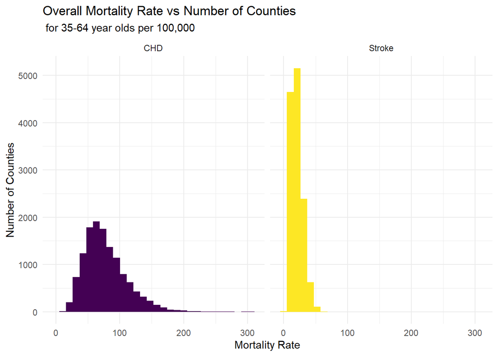

### RQ1 - Age

To begin, we will examine the impact of age on the mortality rate for both stroke and CHD. The data set yielded two age groups: those aged 35 to 64 and those aged 65 and older. We will remove the rows that were not associated with a change in age; in particular, we removed the rows with the value “Overall” for age because these rows are used for analysis of other categories when age is not a factor. We obtain 51,300 rows as a result of this filtration[^5]. The graph below depicts this data set and shows the drastic change in proportion for both CHD and stroke deaths between both age groups, despite the fact that CHD has a higher proportion overall.

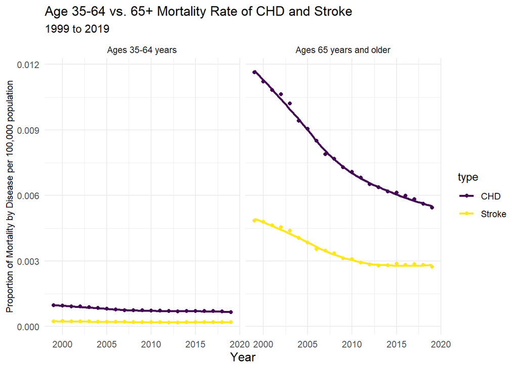

#### Hypothesis Tests:

Using the data shown above, we will now run the following hypothesis test. This test will determine whether the average morality rate for all counties, races, and genders in the age group of 35 to 64 is equal to or not equal to the average morality rate for those aged 65 and older under the same conditions. To control the influence on death and compare the two causes of death, we will test the hypothesis separately for each cause of death, stroke and CHD. Based on the central limit theorem, we will assume that the mean distribution is approximately normal for each of the hypothesis tests.

**Coronary Heart Disease Hypothesis Tests:**

- We will assume that there is a universal parameters $\mu_{\text{35-64}}$ and $\mu_{\text{65+}}$ representing the mean of mortality due to coronary heart disease per year under the experimental conditions aged 35 - 64 and those aged 65 and older, respectively.
- Assume the distribution of the mean of mortality due to coronary heart disease is approximately normal
- Assume that all trials are independent.

Model:

$X_i \sim N(\mu_{\text{35-64}}, \sigma_{\text{35-64}}), \quad i = 1, \ldots, n_1$  
$Y_i \sim N(\mu_{\text{65+}}, \sigma_{\text{65+}}), \quad i = 1, \ldots, n_2$

Hypotheses:

$H_0: \mu_{\text{35-64}} = \mu_{\text{65+}}$  
$H_a: \mu_{\text{35-64}} \neq \mu_{\text{65+}}$

Test statistic:

$t = \frac{\bar{x} - \bar{y}}{\text{SE}(\bar{x} - \bar{y})}$

```
##
##  Welch Two Sample t-test
##
## data:  x and y
## t = -270.64, df = 13037, p-value < 2.2e-16
## alternative hypothesis: true difference in means is not equal to 0
## 95 percent confidence interval:
##  -719.3276 -708.9829
## sample estimates:
## mean of x mean of y
##   77.7262  791.8815
```

There is very strong evidence that the mean mortality rate of those aged 35 to 64 who died from coronary heart disease is not equal than the mean of the mortality rate of those aged 65 and older from heart disease (t-stat = -270.64 on 13037 df, $p = 2.2e-16$, two-sided t-test, unequal variances).

**Stroke Hypothesis Tests:**

- We will assume that there is a universal parameters $\mu_{\text{35-64}}$ and $\mu_{\text{65+}}$ representing the mean of mortality due to stroke per year under the experimental conditions aged 35 - 64 and those aged 65 and older, respectively.
- Assume the distribution of the mean of mortality due to stroke is approximately normal
- Assume that all trials are independent.

Model:

$X_i \sim N(\mu_{\text{35-64}}, \sigma_{\text{35-64}}), \quad i = 1, \ldots, n_1$  
$Y_i \sim N(\mu_{\text{65+}}, \sigma_{\text{65+}}), \quad i = 1, \ldots, n_2$

Hypotheses:

$H_0: \mu_{\text{35-64}} = \mu_{\text{65+}}$  
$H_a: \mu_{\text{35-64}} \neq \mu_{\text{65+}}$

Test statistic

$t = \frac{\bar{x} - \bar{y}}{\text{SE}(\bar{x} - \bar{y})}$

[output not shown]

There is very strong evidence that the mean mortality rate of those aged 35 to 64 who died from stroke is not equal to than the mean of the mortality rate of those aged 65 and older from heart disease (t-stat = -293.92 on 12741 df, $p = 2.2e-16$, two-sided t-test, unequal variances).

**Age Influence on Heart Disease vs. Stroke:**

We will now compare the difference in mortality rate per 100,000 population between the two deaths. Through the graph, it is shown that the average mortality rate for CHD is higher among those aged 65 and older compared to those who died from stroke. The average is comparable for the people aged 35 to 64, though.

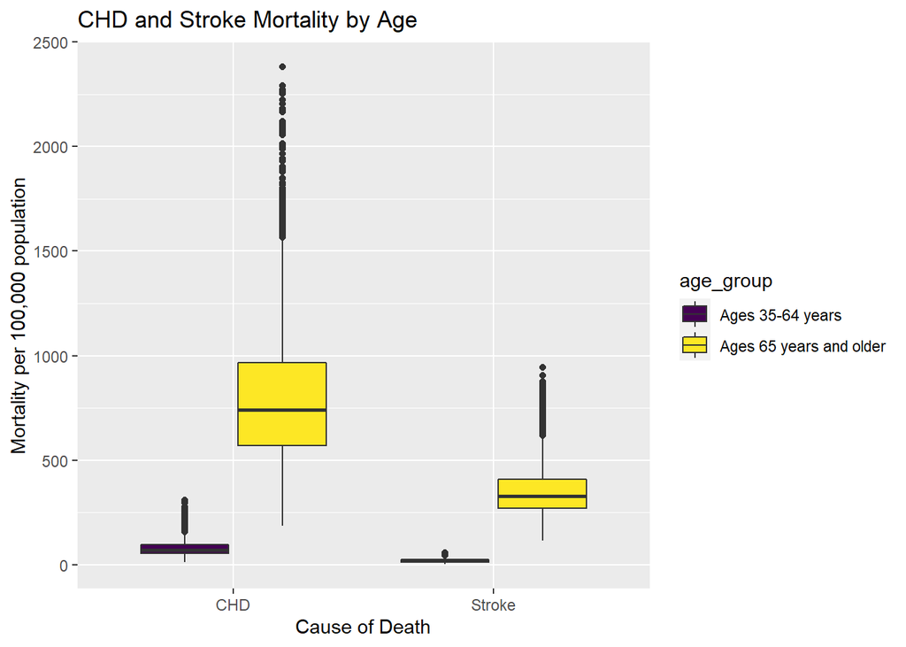

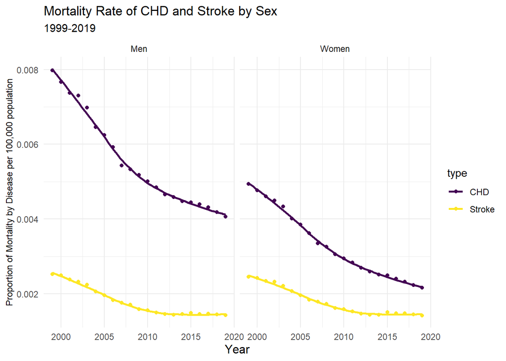

#### Hypothesis Tests:

This hypothesis test will determine whether the average mortality rate is the same for both sexes (male and female) or if they differ. To control the influence on death, we test the hypothesis for each cause of death separately. The assumptions are similar to the tests done in the first steps, under the same condition of the central limit theorem.

**Coronary Heart Disease Hypothesis Tests:**

- We will assume that there is a universal parameters $\mu_{\text{female}}$ and $\mu_{\text{male}}$ representing the mean of female and male mortality due to coronary heart disease per year, respectively.
- Assume that all trials are independent
- Assume the distribution of the mean of mortality due to coronary heart disease is approximately normal

Model:

$X_i \sim N(\mu_{\text{female}}, \sigma_{\text{female}}), \quad i = 1, \ldots, n_1$  
$Y_i \sim N(\mu_{\text{male}}, \sigma_{\text{male}}), \quad i = 1, \ldots, n_2$

Hypotheses:

$H_0: \mu_{\text{female}} = \mu_{\text{male}}$  
$H_a: \mu_{\text{female}} \neq \mu_{\text{male}}$

Test statistic:

$t = \frac{\bar{x} - \bar{y}}{\text{SE}(\bar{x} - \bar{y})}$

```
##
##  Welch Two Sample t-test
##
## data:  x and y
## t = -57.121, df = 43777, p-value < 2.2e-16
## alternative hypothesis: true difference in means is not equal to 0
## 95 percent confidence interval:
##  -233.0911 -217.6256
## sample estimates:
## mean of x mean of y
##  330.9610  556.3194
```

There is very strong evidence that the mean mortality rate of women who died from coronary heart disease does not equal the mean of the mortality rate of men from heart disease (t-stat = -57.121 on 43777 df, $p = 2.2e-16$, two-sided t-test, unequal variances, extreme test statistic).

**Stroke Hypothesis Tests:**

- We will assume the same assumptions and definition of the $\mu_{\text{female}}$ and $\mu_{\text{male}}$ parameters as the hypothesis above.

Model:

$X_i \sim N(\mu_{\text{female}}, \sigma_{\text{female}}), \quad i = 1, \ldots, n_1$  
$Y_i \sim N(\mu_{\text{male}}, \sigma_{\text{male}}), \quad i = 1, \ldots, n_2$

Hypotheses:

$H_0: \mu_{\text{female}} = \mu_{\text{male}}$  
$H_a: \mu_{\text{female}} \neq \mu_{\text{male}}$

Test statistic

$t = \frac{\bar{x} - \bar{y}}{\text{SE}(\bar{x} - \bar{y})}$

```
##
##  Welch Two Sample t-test
##
## data:  x and y
## t = -0.098442, df = 49773, p-value = 0.9216
## alternative hypothesis: true difference in means is not equal to 0
## 95 percent confidence interval:
##  -3.281428  2.967570
## sample estimates:
## mean of x mean of y
##  178.9263  179.0832
```

**Sex Influence on Heart Disease vs. Stroke:**

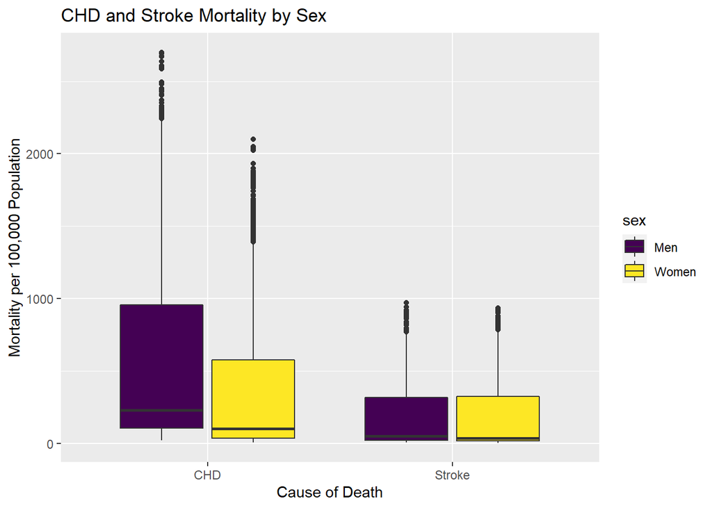

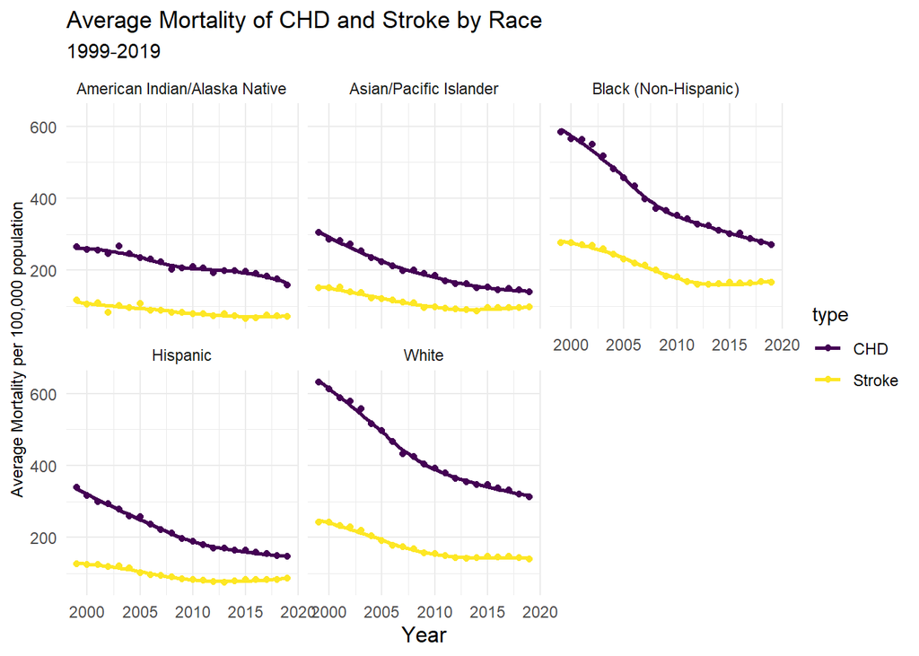

#### Hypothesis Tests:

These two hypothesis tests will be used to determine whether the average CHD mortality rate is the same between black and all others races or if the average stroke mortality rate is the same between asians and all other races, or if they do not equal each other. The following races are represented in the data set: Black (non-Hispanic), Hispanic, White, American Indian/Alaska Native, and Asian/Pacific Islander. To control the influence on death, we test the hypothesis for each cause of death separately. We will keep the same assumptions as above that are defined under the central limit theorem.

**Coronary Heart Disease Hypothesis Tests:**

- We will assume that there is a universal parameters $\mu_{\text{all other}}$ and $\mu_{\text{black}}$ representing the mean mortality due to coronary heart disease per year over all races, sex, and age, and the mean mortality due to coronary heart disease of non-Hispanic black people, respectively.
- Assume that all trials are independent.

Model:

$X_i \sim N(\mu_{\text{all other}}, \sigma_{\text{all other}}), \quad i = 1, \ldots, n_1$  
$Y_i \sim N(\mu_{\text{black}}, \sigma_{\text{black}}), \quad i = 1, \ldots, n_2$

Hypotheses:

$H_0: \mu_{\text{all other}} = \mu_{\text{black}}$  
$H_a: \mu_{\text{all other}} < \mu_{\text{black}}$

Test statistic:

$t = \frac{\bar{x} - \bar{y}}{\text{SE}(\bar{x} - \bar{y})}$

```
##
##  Welch Two Sample t-test
##
## data:  x and y
## t = -16.225, df = 21573, p-value < 2.2e-16
## alternative hypothesis: true difference in means is less than 0
## 95 percent confidence interval:
##       -Inf -57.91307
## sample estimates:
## mean of x mean of y
##  335.3656  399.8122
```

**Stroke Hypothesis Tests:**

- We will assume that there is a universal parameters $\mu_{\text{all other}}$ and $\mu_{\text{asian}}$ representing the mean mortality due to stroke per year over all races, sex, and age, and the mean mortality due to stroke of Asians respectively.
- Assume that all trials are independent.

Model:

$X_i \sim N(\mu_{\text{all other}}, \sigma_{\text{all other}}), \quad i = 1, \ldots, n_1$  
$Y_i \sim N(\mu_{\text{asian}}, \sigma_{\text{asian}}), \quad i = 1, \ldots, n_2$

Hypotheses:

$H_0: \mu_{\text{all other}} = \mu_{\text{asian}}$  
$H_a: \mu_{\text{all other}} > \mu_{\text{asian}}$

Test statistic:

$t = \frac{\bar{x} - \bar{y}}{\text{SE}(\bar{x} - \bar{y})}$

```
##
##  Welch Two Sample t-test
##
## data:  x and y
## t = 27.923, df = 9800.6, p-value < 2.2e-16
## alternative hypothesis: true difference in means is greater than 0
## 95 percent confidence interval:
##  46.38748      Inf
## sample estimates:
## mean of x mean of y
##  161.7257  112.4344
```

**Race Influence on Heart Disease vs. Stroke:**

Overall, CHDs appear to have significantly more variable mortality rates compared to strokes, as seen by both larger third quartiles and significantly larger outliers in the graph. Additinally, both distributions of the mortality rate across the races are not uniform, which implies that the mortality rates of all the races are not the same, so race is likely associated with mortality rate.

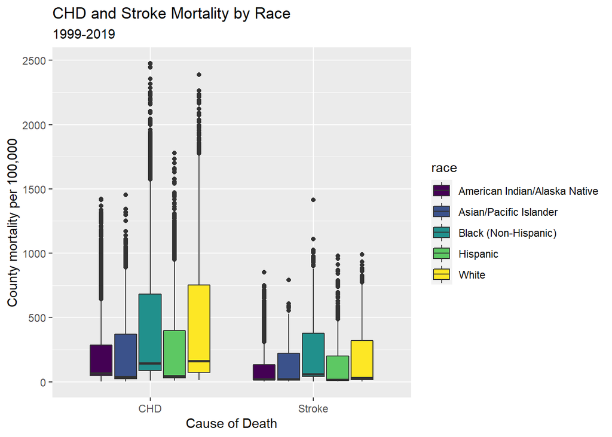

### Analysis Summary

# Discussion

Based on our data analysis, we can conclude that age, race, and gender have some relationship with the mortality rate of CHD, stroke, or both. The conclusions based on the hypothesis tested above show evidence against the mean mortality rate of those aged 35 to 64 who died from both coronary heart disease and stroke being equal to the mean mortality rate of those aged 65 and older with their corresponding death. Similarly, there is compelling evidence that the mean mortality rate of women dying from coronary heart disease is not equal to the mean mortality rate of men dying from heart disease. In the case of stroke, however, there was insufficient evidence to support this association based on the patient’s gender. Finally, we discovered that the mean CHD mortality rate of Non-Hispanic Black people was disproportionately higher than the average of all other races. Furthermore, there is strong evidence that the mean stroke mortality rate of Asians is disproportionately lower than that of all other races. We can see from this analysis that there was a difference in means between the racial groups and the overall average.

There are two shortcomings in our project. First, we are not able to create a generalization for the entire U.S. because certain states are not included in the data, which could be solved if we had data from every U.S. state. Additionally, we may have drawn conclusions predicated on faulty assumptions. For example, such as the reporting of who dies from a CHD or a stroke might actually be biased and non-indicative of the overall parent population of everyone, not random, so we cannot assume that the data is random. This is seen in our exploration of RQ1, which shows that despite our assuming that the data conforms to the Central Limit Theorem because N > 30, it does not. Therefore there must be a non-sampling bias in our data, which in order to be rectified would need to have the CDC implement better sampling procedures and have the analysis re-ran on that data set.

Furthermore, another research question that could have been investigated further by combining this data set with another is how these mortality rates compare to factors such as smoking, obesity rate, and others. In essence, the study would look for another variable associated with changes in CHD and stroke mortality rates over time in order to improve our understanding of the cause of death. To properly depict and draw conclusions from this data, we would need to collect additional data on these variables, such as a full medical record or something similar. This could have greatly aided the expansion of our research questions by including a smoking history, pre-existing conditions, or whether the disease is hereditary. We could also have used linear regression to see if there was a linear model that fit the data and could be used to predict mortality rates based on demographics.

Based on our data and analysis, we discovered a link between patient demographics (race, gender, and age) and the mortality rates of two cardiovascular diseases: stroke and coronary heart disease. There were also some differences between the two, such as higher variability in CHD rates compared to stroke. Other factors that influenced these outcomes that we did not investigate may have reduced the accuracy of the data; however, based on the assumptions we made, we have provided evidence against or in support of some of these correlating factors.

[^1]: https://www.cdc.gov/stroke/facts.htm#:~:text=Stroke%20statistics,-In%202020%2C%201&text=Every%2040%20seconds%2C%20someone%20in,minutes%2C%20someone%20dies%20of%20stroke.&text=Every%20year%2C%20more%20than%20795%2C000,are%20first%20or%20new%20strokes.
[^2]: https://www.cdc.gov/heartdisease/facts.htm
[^3]: https://www.cdc.gov/heartdisease/about.htm
[^4]: `{r, warning = FALSE} # Cleaning Data # data = all_data %>% # select(Year,LocationAbbr, LocationDesc, Topic, Data_Value, Stratification1, Stratification2, Stratification3) %>% # rename(year = Year, state = LocationAbbr, county = LocationDesc, age_group = Stratification1, data = Data_Value, type = Topic, race = Stratification2, sex = Stratification3) %>% # filter(!is.na(data)) %>% # arrange(year) %>% # mutate( type = recode(type, "Coronary heart disease (CHD)" = "CHD", "All stroke" = "Stroke"))`
[^5]: `{r, warning = FALSE} # age_data= data %>% # filter(type != "Heart failure" & type != "Cardiovascular disease (CVD)" & type != "All heart disease") %>% # filter(race == "Overall", (sex == "Overall")) %>% # select(year, state, county, type, data, age_group) # age_data # # age_sum = age_data %>% # group_by(age_group, year, type) %>% # mutate(c = n(), # n = c*100000, # total = sum(data)) %>% # distinct(total, c,n) %>% # mutate(p = total/n) # # pivot_age = age_sum %>% pivot_wider(names_from = type, values_from = c(c, total, n, p)) %>% rename( # n_heart = "n_CHD", # p_heart = "p_CHD", # p_stroke = "p_Stroke", # n_stroke = "n_Stroke", # c_stroke = "c_Stroke", # c_heart = "c_CHD", # total_stroke = "total_Stroke", # total_heart = "total_CHD" # )`
[^6]: `{r, warning = FALSE} # sex_data= data %>% # filter(type != "Heart failure" & type != "Cardiovascular disease (CVD)" & type != "All heart disease", race == "Overall", sex != "Overall") %>% # select(!race) # sex_data # # sex_sum = sex_data %>% # group_by(sex, year, type) %>% # mutate(c = n(), # n = c*100000, # total = sum(data)) %>% # distinct(total, c,n) %>% # mutate(p = total/n)`
[^7]: `{r, warning = FALSE, include = FALSE} # race_data= data %>% # filter(type != "Heart failure" & type != "Cardiovascular disease (CVD)" & type != "All heart disease", race != "Overall", sex == "Overall") %>% # select(!sex) # # race_sum = race_data %>% # group_by(race, year, type) %>% # mutate(c = n(), # n = c*100000, # total = sum(data), # mean = mean(data)) %>% # distinct(total, c,n, mean) %>% # mutate(p = total/n) # race_sum`